# Introduction to Probability and Statistics: Syllabus

*MATH 141, Fall 2015*  
*Instructor: Andrew Bray*  
*Office hours: Mon/Tue 2-5 pm, Wed 2-4 pm*

Welcome to the Age of Data, where information is all around us, helping us live happier, healthier lives. Or does it? Do we know yet if cell phones cause cancer? Have we come to a decision on whether we should be eating lots of meat or none at all to stay healthy? Despite all of this information, it can be challenging to turn it into the knowledge from which we can make sound decisions.

Statistics is the field that aims to bridge this gap between information and knowledge and this course is an application-oriented introduction to modern statistical modeling and inference. We will discuss topics such as: study design, descriptive statistics, data visualization, random variables, probability and sampling distributions, point and interval estimates, hypothesis tests, resampling procedures, and multiple regression. A wide variety of applications from the natural and social sciences will be used.

### Textbook

[OpenIntro: Introductory Statistics with Randomization and Simulation](https://www.openintro.org/stat/textbook.php?stat_book=isrs) (2014), by Diez, Barr and Çetinkaya-Rundel, available in three formats: pdf, tablet-friendly pdf, and paperback edition. The textbook is free and open-source, but you’re encouraged to purchase the paperback edition through amazon for < $10.

The textbook is a key component of the course. Our class will maintain a reading group at nb.mit.edu, which provides us with a communal annotation engine. You will be asked to make and respond to reading notes online, as class time will focus on activities to help understand concepts.

### Class components

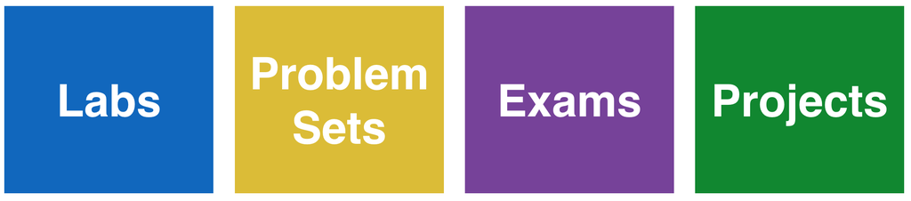

#### Labs

We meet in the laboratory (ETC 211) every Tuesday to tinker around with data and statistics. Our tools of choice are R and RStudio, software that vastly amplifies your power to explore, visualize, and model data. Reed’s RStudio server is accessible by going to https://rstudio.reed.edu/ and using your college login.

Every week you’ll be working with a new data set and organizing your work in an RMarkdown document. These will be submitted through moodle and will be due the following Monday morning at 10 am.

#### Problem Sets

There will be weekly problem sets to reinforce the concepts from the readings as well as the material that we address in class. You’re encouraged to work on the problem sets with fellow students, though you’ll both need to turn in your own work.

#### Exams

We’ll have several examinations throughout the semester in order to challenge your understanding and provide me with a sense of where you’re at. Some will be more traditional pen and paper and others are to be done with the computer using R.

#### Projects

The best way to improve your skill in statistics is to do statistics on a real problem. There will be two small projects this semester that where you’ll have the opportunity to go through a full statistical analysis from soup to nuts.

#### More Resources

Dedicated tutors will be available at the DoJo, times TBA.